# IA1

Jake VanCampen

Nov 05 2017

```r
knitr::opts_chunk$set(message=FALSE, warning = FALSE)
```

## Enriched diet affects zebrafish size

To study the effects of an enriched diet on mean zebrafish size, 200 freshly hatched zebrafish were taken from the same clutch and randomly assigned to an enriched or a control diet (unenriched). The diet was administered for two months at which point the standard length (mm) and mass (mg) of each fish was measured. Results were compiled in a tab-separated file containing the following columns: “Individual”, “Diet”, “SL”, and “Weight.”

The following are the hypothesis to be tested in this experiment:

$$H{_0} \text{: Feeding zeebrafish an enriched diet will not significantly affect their mean size after two months}$$
$$H{_A} \text{: Feeding zebrafish an enriched diet will significantly affect their mean size after two months}$$

### Exploratory Data Analysis

```r
library(tidyverse)
library(magrittr)
library(ggpubr)
library(knitr)
library(lmodel2)
library(broom)
zfish_raw <- read_tsv('zfish_diet_IA.tsv')
head(zfish_raw)
```

```
## # A tibble: 6 x 4
##   Individual     Diet    SL Weight
##        <int>    <chr> <dbl>  <dbl>
## 1          1  Control  3.58  0.554
## 2          2 Enriched  4.66  0.699
## 3          3 Enriched  4.50  0.644
## 4          4  Control  3.71  0.624
## 5          5  Control  4.36  0.688
## 6          6  Control  3.89  0.613
```

### Histograms

To look at how these data are distributed, histograms of the continuous variables were plotted.

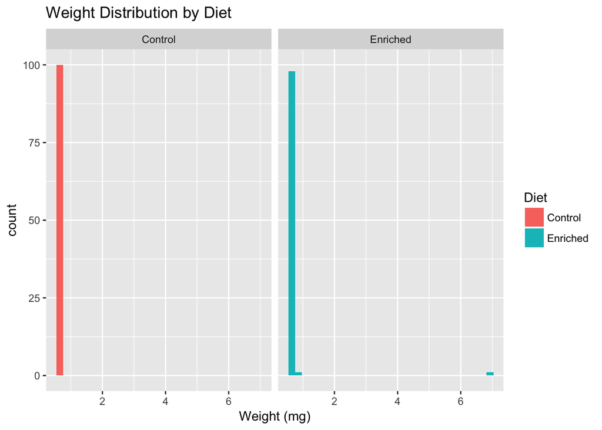

```r
ggplot(zfish_raw, aes(fill = Diet))+
  geom_histogram(aes(Weight))+
  facet_wrap(~Diet)+
  xlab('Weight (mg)')+
  ggtitle('Weight Distribution by Diet')
```

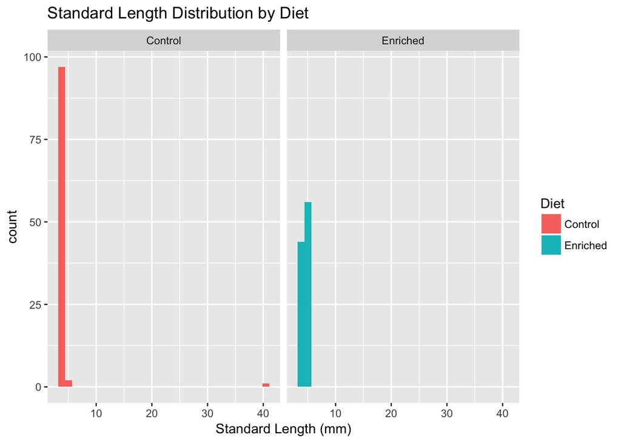

```r
ggplot(zfish_raw, aes(fill = Diet))+
  geom_histogram(aes(SL))+
  facet_wrap(~Diet)+
  xlab('Standard Length (mm)') +
  ggtitle('Standard Length Distribution by Diet')
```

There appear to be erroneous data that is obscuring the distribution of both SL, and Weight. These data were removed as shown below, and histograms of the continuous variables are plotted again.

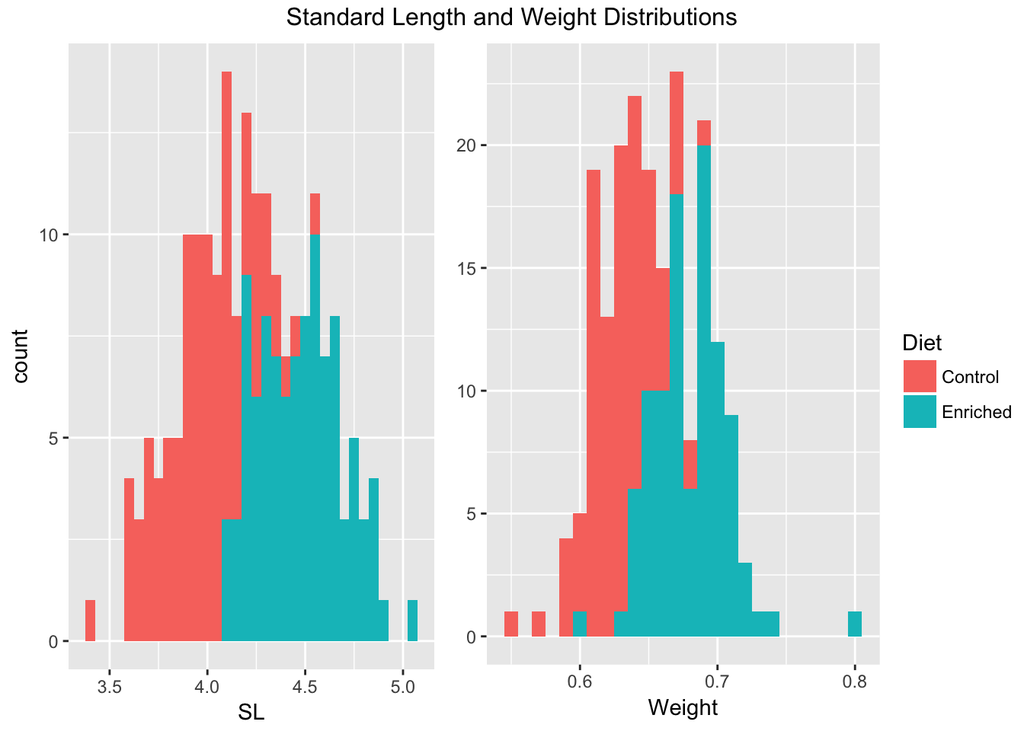

```r
zfish_correct <- zfish_raw %>%
  filter(., Weight < 4 & SL < 20)


# total SL hist colored by diet
dt_n <- ggplot(zfish_correct, aes(SL, fill = Diet))+
            geom_histogram(binwidth = 0.05)


# SL hist faceted by diet
dt <- ggplot(zfish_correct, aes(SL, fill = Diet)) +
          geom_histogram(binwidth = 0.05)+
          facet_grid(Diet~.)+
          xlab('Standard Length (mm)') +
  theme(
  strip.text.x = element_blank(),
  strip.text.y = element_blank()
)


# total weight hist colored by diet
wt_n <- ggplot(zfish_correct, aes(Weight, fill = Diet)) +
            geom_histogram(binwidth = 0.01)+
            theme(axis.title.y = element_blank())

# weight hists faceted by diet
wt <- ggplot(zfish_correct, aes(Weight, fill = Diet)) +
  geom_histogram(aes(Weight, fill = Diet), binwidth = 0.007) +
  facet_grid(Diet~.)+
  xlab('Weight (mg)') +
  theme(
  strip.text.x = element_blank(),
  strip.text.y = element_blank(),
  axis.title.y = element_blank()
)


# group figures
ggarrange(dt_n, wt_n, common.legend = TRUE, legend = 'right') %>% annotate_figure(., top = text_grob("Standard Length and Weight Distributions"))
```

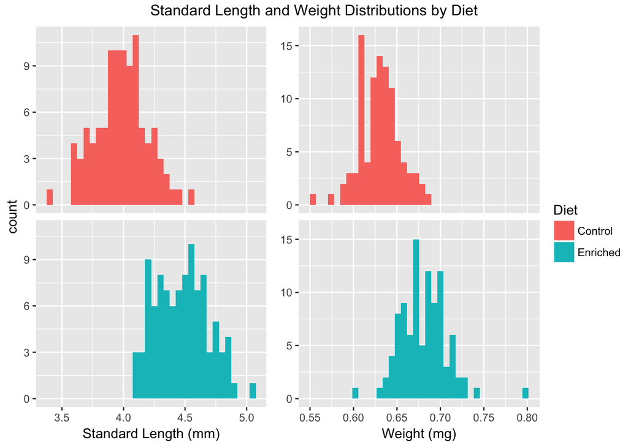

```r
ggarrange(dt, wt, common.legend = TRUE, legend = 'right') %>% annotate_figure(., top = text_grob("Standard Length and Weight Distributions by Diet"))
```

Without the obvious data errors, these data look normally distributed. The histograms of continuous variables split by diet show a positive shift in both continuous variables for the enriched diet compared to the control, let’s do some statistics to back this up!

### Boxplots

First similar comparisons will be made using boxplots.

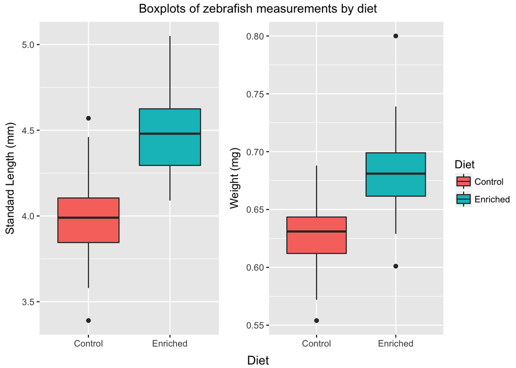

```r
bp_d <- ggplot(zfish_correct, aes(Diet, SL, fill = Diet))+
  geom_boxplot() +
  ylab('Standard Length (mm)')+
  theme(
    axis.title.x = element_blank()
  )

bp_w <- ggplot(zfish_correct, aes(Diet, Weight, fill = Diet))+
  geom_boxplot()+
  ylab('Weight (mg)')+
  theme(
    axis.title.x = element_blank()
    )

ggarrange(bp_d, bp_w, common.legend = TRUE, legend = 'right')  %>%
          annotate_figure(.,
                          top = text_grob(
                          "Boxplots of zebrafish measurements by diet"),
                          bottom = text_grob('Diet'))
```

Again we see the overall increase in both metrics with an enriched diet as compared to the control.

### Summary statistics

And a summary table to compare relevant statistics:

```r
Summ_stats <- zfish_correct %>%
  group_by(Diet) %>%
  summarise_at(vars(SL, Weight), c('mean', 'sd', 'var'))

kable(Summ_stats,
      align = 'c',
      caption = 'Summary statistics for zebra fish measuremnets by diet',
      digits = 3)
```

Summary statistics for zebra fish measuremnets by diet

| Diet | SL_mean | Weight_mean | SL_sd | Weight_sd | SL_var | Weight_var |
| --- | --- | --- | --- | --- | --- | --- |
| Control | 3.982 | 0.630 | 0.211 | 0.023 | 0.045 | 0.001 |
| Enriched | 4.473 | 0.681 | 0.213 | 0.027 | 0.046 | 0.001 |

### T Test

Because the data look to be normally distributed, appear to have equal variances (var[control] ~= var[diet]), and occur as independant observations, the distributional assumptions are met to perform a parametric T Test. The T Test will test a difference in the means of the Control and Enriched treatments for both weight, and standard length.

```r
# T tests for each
sl_T <- t.test(zfish_correct$SL ~ zfish_correct$Diet)
wt_T <- t.test(zfish_correct$Weight ~ zfish_correct$Diet)


# format for reporting t test
t.report <- function(tt){
  tvalue <- tt$statistic %>% formatC(digits = 2, format = "f")
  pvalue <- tt$p.value %>% formatC(digits = 2, format = "E")
  if (round(tt$parameter, 0) == tt$parameter) {
    df <- tt$parameter
  } else {
    df <- formatC(tt$parameter, digits = 2, format = "f")
  }
  if (tt$p.value < 0.0005) {
    pvalue <- " < 0.001"
  } else {
    if (tt$p.value < 0.005) {
      pvalue <- paste0(" = ",
                       tt$p.value %>%
                         formatC(., digits = 3, format = "f"))
    } else {
      pvalue <- paste0(" = ",
                       tt$p.value %>%
                         formatC(., digits = 2, format = "f"))
    }
    }
  paste0("*t*(",df,") = ",tvalue, ", *p*", pvalue)
  }
```

Now the statement can be made that zebrafish have a significantly higher standard length when fed an enriched diet as compared to a normal diet, *t*(195.98) = -16.27, *p* < 0.001, and have a significantly higher weight when fed an enriched diet as compared to a normal diet, *t*(190.90) = -14.08, *p* < 0.001. The null hypothesis that there is no significant effect of an enriched diet on mean fish size can be rejected.

### Non-parametric T test

The hypothesis testing can be done using a non-parametric parameter estimation (calculated by resampling of the means) and then performing a T-test. This resampling will cooerce the distribution of the parameter estimate into normality (if the data are not already normally distributed) before performing hypothesis tests, such that our confidence interval about the the hypothesis test is valid.

```r
# bootstrap resampling of the t statistic

# filter control and enriched
Control <- zfish_correct %>% filter(., Diet == 'Control')
Enriched <- zfish_correct %>% filter(., Diet == 'Enriched')


# bootstrap resampling of the standard length
# generate a null distribution of T-values by
# resampling from the same distribution
t_boot_SL <- NULL
for (i in 1:10000) {
  c_new_SL <- sample(Control$SL, 100, replace = T)
  c_mean_sl <- mean(c_new_SL)
  c_var_sl <- var(c_new_SL)
  c_nSL <- length(c_new_SL)

  e_new_SL <- sample(Control$SL, 100, replace = T)
  e_mean_sl <- mean(e_new_SL)
  e_var_sl <- var(e_new_SL)
  e_nSL <- length(e_new_SL)

  t_boot_SL[i] <- (c_mean_sl - e_mean_sl) / sqrt(((c_nSL-1)*c_var_sl+(e_nSL-1)*e_var_sl)/(c_nSL+e_nSL)*((1/c_nSL)+(1/e_nSL)))
}


# mean of the null distribution
mean(t_boot_SL)
```

```
## [1] 0.006077307
```

```r
# bootsrap standard error
sd(t_boot_SL)
```

```
## [1] 1.013642
```

```r
#The approximate 95% Confidence Interavals for t
CI.l.SL <- quantile(t_boot_SL, 0.025)
CI.h.SL <- quantile(t_boot_SL, 0.975)




#
# bootstrap resampling of the weight
# generate a null distribution of T-values by
# resampling from the same distribution
t_boot_WT <- NULL
for (i in 1:10000) {
  c_new_WT <- sample(Control$Weight, 100, replace = T)
  c_mean_WT <- mean(c_new_WT)
  c_var_WT <- var(c_new_WT)
  c_nWT <- length(c_new_WT)

  e_new_WT <- sample(Control$Weight, 100, replace = T)
  e_mean_WT <- mean(e_new_WT)
  e_var_WT <- var(e_new_WT)
  e_nWT <- length(e_new_WT)

  t_boot_WT[i] <- (c_mean_WT - e_mean_WT) / sqrt(((c_nWT-1)*c_var_WT+(e_nWT-1)*e_var_WT)/(c_nWT+e_nWT)*((1/c_nWT)+(1/e_nWT)))
}


# mean of the null distribution
mean(t_boot_WT)
```

```
## [1] 0.002477214
```

```r
# bootsrap standard error
sd(t_boot_WT)
```

```
## [1] 1.023866
```

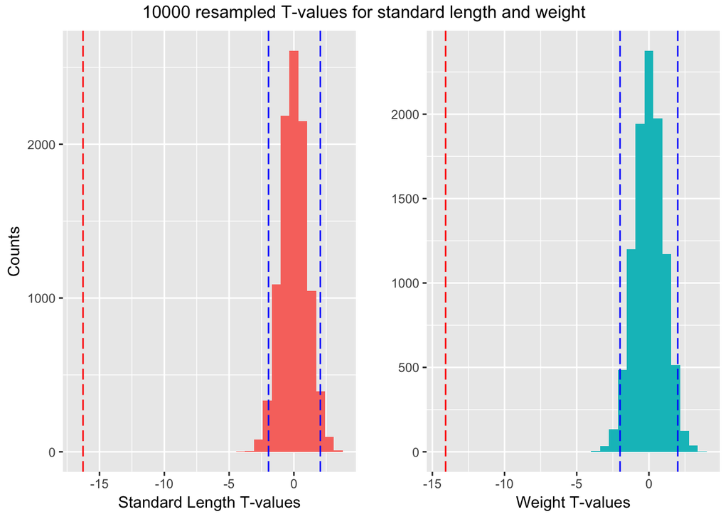

```r
#The approximate 95% Confidence Interavals for t
CI.l.WT <- quantile(t_boot_WT, 0.025)
CI.h.WT <- quantile(t_boot_WT, 0.975)


# emulate ggplot color palate
gg_color_hue <- function(n) {
  hues = seq(15, 375, length = n + 1)
  hcl(h = hues, l = 65, c = 100)[1:n]
}


# plot the parametric t values along with
# null distribution of t-statistics
t_bootSL <- ggplot(tbl_df(t_boot_SL), aes(value))+
  geom_histogram(fill = gg_color_hue(2)[1])+
  geom_vline(xintercept = CI.l.SL, colour = 'blue', linetype = 'longdash')+
  geom_vline(xintercept = CI.h.SL, color = 'blue', linetype = 'longdash') +
  geom_vline(xintercept = sl_T$statistic, color = 'red', linetype = 'longdash')+
  xlab('Standard Length T-values') +
  ylab('Counts')


t_bootWT <- ggplot(tbl_df(t_boot_WT), aes(value))+
  geom_histogram(fill = gg_color_hue(2)[2])+
  geom_vline(xintercept = CI.l.WT, colour = 'blue', linetype = 'longdash')+
  geom_vline(xintercept = CI.h.WT, color = 'blue', linetype = 'longdash') +
  geom_vline(xintercept = wt_T$statistic, color = 'red', linetype = 'longdash')+
  xlab('Weight T-values') +
  ylab('')


ggarrange(t_bootSL, t_bootWT) %>% annotate_figure(top = '10000 resampled T-values for standard length and weight')
```

The distribution of 10000 bootstrapped t-values for a null hypothesis of no difference shows that the upper and lower 95% confidence intervals for t-values accepting the null hypothesis are around 2. Given that the parametric estimate for the null hypothesis is t_SL =-16.2741134 and t_WT = -14.0797545 (red dotted lines), the null hypothesis of no difference can be rejected.

### SL AND WEIGHT

```r
#type I model fit
zfish_lm <- lm(zfish_correct$Weight~zfish_correct$SL)
b <- format(data.frame(tidy(zfish_lm))$estimate[1],digit = 3)
m <- format(data.frame(tidy(zfish_lm))$estimate[2],digits = 3)
glance(zfish_lm)
```

```
##   r.squared adj.r.squared      sigma statistic      p.value df   logLik
## 1 0.8934216     0.8928779 0.01168033  1643.022 3.097717e-97  2 601.1253
##         AIC       BIC   deviance df.residual
## 1 -1196.251 -1186.386 0.02674031         196
```

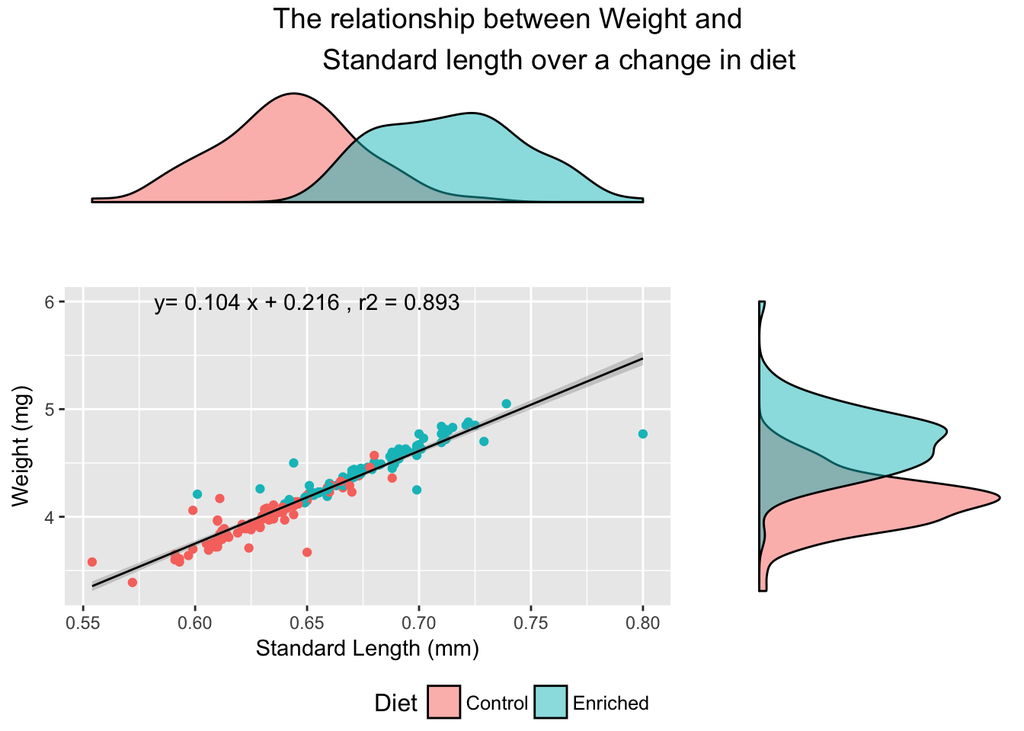

```r
r2 <- format(data.frame(glance(zfish_lm)$r.squared)[[1]], digits = 3)

eq <- paste("y=", m, "x +", b,',', 'r2', "=", r2)


# plot the relationship between standard lenght and weight
corr <- ggplot(zfish_correct, aes(zfish_correct$Weight,
                          zfish_correct$SL,
                          color = Diet)) +
  geom_point() +
  geom_smooth(method = 'lm', color = 'black', size = 0.5) +
  xlab('Standard Length (mm)') +
  ylab('Weight (mg)')+
  annotate('text',x = 0.65, y = 6, label = eq)

sl_dens <- ggdensity(zfish_correct, 'SL', fill = 'Diet') +
           clean_theme()

wt_dens <- ggdensity(zfish_correct, 'Weight', fill = 'Diet') +
           rotate() + clean_theme()

# Arranging the plot
ggarrange(sl_dens, NULL, corr, wt_dens,
          ncol = 2, nrow = 2,  align = "hv",
          widths = c(2, 1), heights = c(1, 2),
          common.legend = TRUE, legend = 'bottom') %>%
          annotate_figure(
            top = text_grob(
            'The relationship between Weight and \
            Standard length over a change in diet',
            size = 14))
```

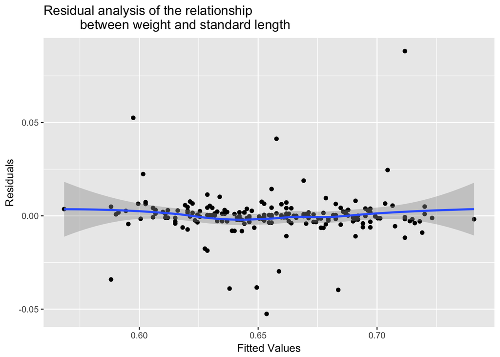

```r
# combine residuals vs. fitted values
res <- tbl_df(data.frame(cbind(zfish_lm$residuals, zfish_lm$fitted.values)))

ggplot(res, aes(X2,X1)) +
  geom_point() +
  geom_smooth(mode = 'lm') +
  xlab('Fitted Values')+
  ylab('Residuals')+
  ggtitle('Residual analysis of the relationship\
          between weight and standard length')
```

```r
# type II model fit
zfish_lm2 <- lmodel2(zfish_correct$Weight~zfish_correct$SL)
tidy(zfish_lm2)
```

```
##   method      term  estimate   conf.low conf.high
## 1     MA Intercept 0.2156807 0.19427461 0.2370645
## 2     MA     Slope 0.1040081 0.09895024 0.1090711
## 3    OLS Intercept 0.2162407 0.19481062 0.2376707
## 4    OLS     Slope 0.1038756 0.09882167 0.1089295
## 5    SMA Intercept 0.1907835 0.16892498 0.2116598
## 6    SMA     Slope 0.1098969 0.10495909 0.1150670
```

```r
glance(zfish_lm2)
```

```
##   r.squared    theta      p.value           H
## 1 0.8934216 0.701477 3.097717e-97 2.50623e-05
```

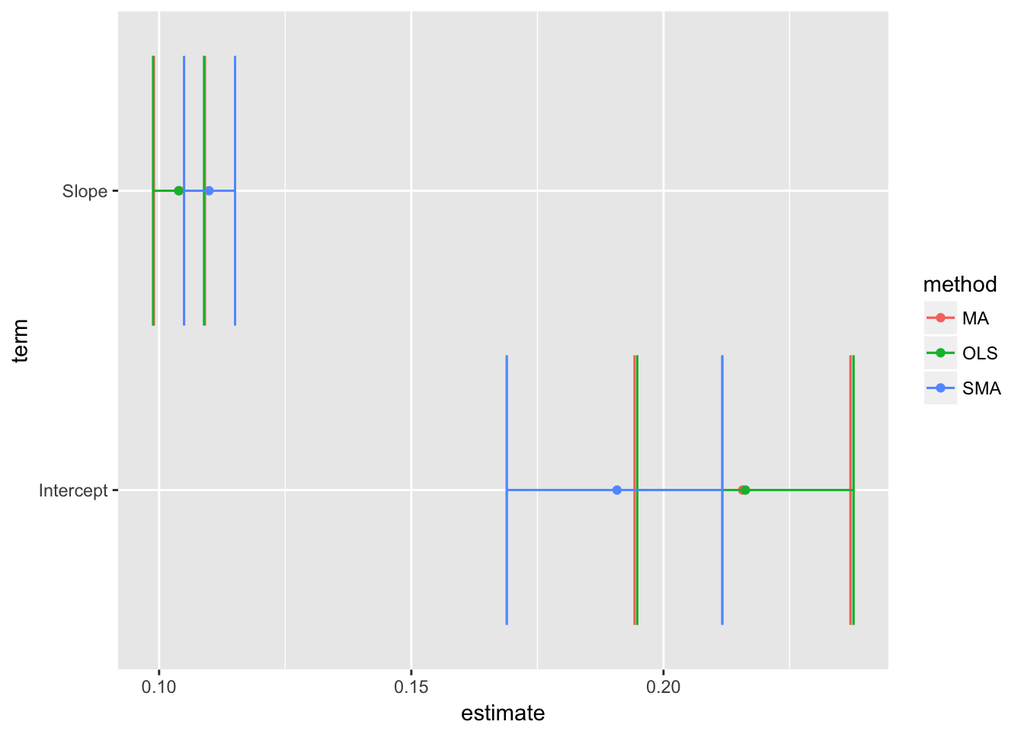

```r
ggplot(tidy(zfish_lm2), aes(estimate, term, color = method)) +
  geom_point() +
  geom_errorbarh(aes(xmin = conf.low, xmax = conf.high)) +
  geom_errorbarh(aes(xmin = conf.low, xmax = conf.high))
```

```r
  tidy(zfish_lm2)
```

```
##   method      term  estimate   conf.low conf.high
## 1     MA Intercept 0.2156807 0.19427461 0.2370645
## 2     MA     Slope 0.1040081 0.09895024 0.1090711
## 3    OLS Intercept 0.2162407 0.19481062 0.2376707
## 4    OLS     Slope 0.1038756 0.09882167 0.1089295
## 5    SMA Intercept 0.1907835 0.16892498 0.2116598
## 6    SMA     Slope 0.1098969 0.10495909 0.1150670
```

There is a significant relationship between Weight(mg) and Standard Length (mm) *F*<sub>1,196</sub> = 1643, *p* < 0.001